# NumPy

1. Converting a List to an array  
2. Arange Function  
3. Multidimensional Array  
4. Size Function  
5. Shape Function  
6. Dtype Function  
7. Ndim Function  
8. Zeros and Ones Function  
9. Eye Function  
10. Empty Function  
11. Random Functions:  
-----a) np.random.rand  
-----b) np.random.randint  
-----c) np.random.randn  
12. Reshape function  
13. Linspace Function  
14. Flatten Function  
15. Logspace Function  
16. Copy Function  
17. arr.max() , arr.min() , arr.sum() functions  
18. Seed function  
19. Sorting in numpy array  
20. Mathematical Operation in Numpy  
-----a) Addition  
-----b) Substraction  
-----c) Multiplication  
-----d) Division  
-----e) Matrix Multiplication  
-----f) Power  
21. Percentile Function  
22. Mean, Variance and Standard Deviation  
23. Filtering an numpy array  
24. Transposing an array  
25. Where function  
26. Merging Arrays  
-----a) Using Concatenate  
-----b) Using vstack and hstack  
27. Splitting Arrays  
28. Turning Pictures into Numpy arrays

```python
import numpy as np
```

## `1. Coverting a List to Array`

```python
lst = [1,2,3,4]

print(type(lst))

arr = np.array(lst)

print(type(arr))

arr = np.array(lst)

print(arr)
```

```
<class 'list'>
<class 'numpy.ndarray'>
[1 2 3 4]
```

## `2. Arrange function`

`The arange([start,] stop[, step,][, dtype]) : Returns an array with evenly spaced elements as per the interval. The interval mentioned is half-opened i.e. [Start, Stop)`

```python
arr = np.arange(1,10,2)
```

## `3. Multidimensional Array`

```python
arr = np.array([[1,2,3],[4,5,6],[7,8,9]])

arr
```

```
array([[1, 2, 3],
       [4, 5, 6],
       [7, 8, 9]])
```

## `4. Size Function`

`In Python, numpy.size() function count the number of elements along a given axis` `(0 - Rows | 1 - Columns)`

```python
arr = np.array([[1,2,3],[4,5,6],[7,8,9],[1,2,3]])

print('Total : ', arr.size)
print('Rows  : ', np.size(arr,0))
print('Cols  : ', np.size(arr,1))

arr
```

```
Total :  12
Rows  :  4
Cols  :  3
```

```
array([[1, 2, 3],
       [4, 5, 6],
       [7, 8, 9],
       [1, 2, 3]])
```

## `5. Shape Function`

`The shape of an array can be defined as the number of elements in each dimension. Dimension is the number of indices or subscripts, that we require in order to specify an individual element of an array`.

```python
arr = np.array([[1,2,3],[4,5,6],[7,8,9],[1,2,3]])

print((np.size(arr,0),np.size(arr,1)))

print(arr.shape)
```

```
(4, 3)
(4, 3)
```

## `6. Dtype Function`

`Every ndarray has an associated data type (dtype) object. This data type object (dtype) informs us about the layout of the array. This means it gives us information about:`

- Type of the data (integer, float, Python object, etc.)
- Size of the data (number of bytes)
- The byte order of the data (little-endian or big-endian)
- If the data type is a sub-array, what is its shape and data type?

```python
arr1 = np.array([1,2,3,1,2,3])
arr2 = np.array([1.2,3.1,2.3])


print(arr1.dtype)
print(arr2.dtype)
```

```
int32
float64
```

## `7. Ndim Function`

`numpy.ndarray.ndim() function return the number of dimensions of an array.`

```python
arr1 = np.array([1,2,3,1,2,3])
arr2 = np.array([[1,2,3],[1,2,3]])

print(arr1.ndim)
print(arr2.ndim)

arr3 = np.array(arr1, ndmin = 3)
print(arr3.ndim)
```

```
1
2
3
```

## `8. Zeros Function`

The numpy.zeros() function returns a new array of given shape and type, with zeros. Syntax:

numpy.zeros(shape, dtype = None)

```python
arr = np.zeros(shape = (3,5), dtype = int)

print(arr)
```

```
[[0 0 0 0 0]
 [0 0 0 0 0]
 [0 0 0 0 0]]
```

## `Ones Function`

`The numpy.ones() function returns a new array of given shape and type, with ones.`

`Syntax: numpy.ones(shape, dtype = None)`

```python
arr = np.ones(shape = (3,5), dtype = int)

print(arr)
```

```
[[1 1 1 1 1]
 [1 1 1 1 1]
 [1 1 1 1 1]]
```

## `9. Eye Function`

`The eye tool returns a 2-D array with 1’s as the diagonal and 0’s elsewhere. The diagonal can be main, upper, or lower depending on the optional parameter k.`

```python
np.eye(4, dtype = int)
```

```
array([[1, 0, 0, 0],
       [0, 1, 0, 0],
       [0, 0, 1, 0],
       [0, 0, 0, 1]])
```

## `10. Empty Function`

`Return am empty array of given shape and type`

```python
np.empty(shape = (5,5))
```

```
array([[1.06601862e-311, 7.60861095e-322, 0.00000000e+000,
        0.00000000e+000, 2.05833592e-312],
       [1.15998412e-028, 4.31603868e-080, 1.94919985e-153,
        1.35717430e+131, 6.98346901e-077],
       [1.81148490e-152, 9.37041222e-076, 1.05117820e-153,
        6.01391519e-154, 1.05121175e-153],
       [7.68132025e+140, 6.01347002e-154, 7.54951879e-096,
        1.95360725e-109, 4.90900643e+252],
       [1.94918511e-153, 6.32672800e+180, 4.74483502e+170,
        4.59210323e-072, 2.56761507e-312]])
```

## `11. Random Functions`

### **a) np.random.rand**

`The numpy.random.rand() function creates an array of specified shape and fills it with random values.`

```python
np.random.rand(3,4)
```

```
array([[0.67131712, 0.28699376, 0.80074157, 0.70277132],
       [0.72999175, 0.24963388, 0.62636138, 0.59975577],
       [0.85873895, 0.77294303, 0.44969906, 0.59793589]])
```

### **b) np.random.randint**

`numpy.random.randint() is one of the function for doing random sampling in numpy. It returns an array of specified shape and fills it with random integers from low (inclusive) to high (exclusive), i.e. in the interval [low, high).`

```python
np.random.randint(low = 1, high = 10, size = 10)
```

```
array([7, 9, 1, 2, 7, 8, 5, 6, 2, 7])
```

### **c) np.random.randn**

The numpy.random.randn() function creates an array of specified shape and fills it with random values as per standard normal distribution.

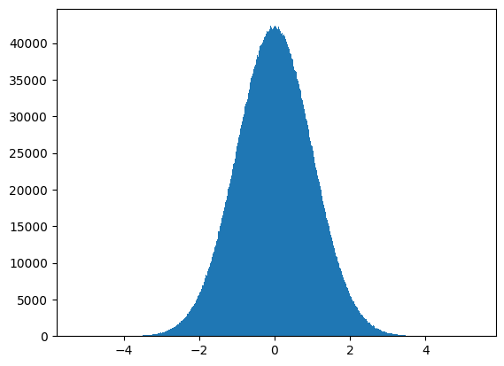

```python
import matplotlib.pyplot as plt

%matplotlib inline

plt.hist(np.random.randn(10000000), bins = 1000);
```

## `12. Reshape function - will not alter the original data`

`The numpy.reshape() function shapes an array without changing the data of the array.<br> It should be noted that the product if the rows and columns should be same`

```python
arr = np.random.randint(1,15,(3,4))

print(arr.shape)
arr = arr.reshape(4,3)
print(arr.shape)
arr = arr.reshape(6,2)

23
print(arr.shape)
```

```
(3, 4)
(4, 3)
(6, 2)
```

## `13. Linspace Function`

`The numpy.linspace() function returns number spaces evenly w.r.t interval. Similar to numpy.arange() function but instead of step it uses sample number.`

Parameters :

- -> start : [optional] start of interval range. By default start = 0
- -> stop : end of interval range
- -> restep : If True, return (samples, step). By default restep = False
- -> num : [int, optional] No. of samples to generate
- -> dtype : type of output array

```python
np.linspace(1,10,5)
```

```
array([ 1.  ,  3.25,  5.5 ,  7.75, 10.  ])
```

## `14. Flatten Function`

`ndarray.flatten() function return a copy of the array collapsed into one dimension`.

```python
arr = np.random.randint(1,15,(3,4))

print(arr.shape)
print(arr)
print('-'*20)
arr = arr.flatten()
print(arr.shape)
print(arr)
```

```
(3, 4)
[[ 3  3  1 12]
 [ 5  1  1 11]
 [ 7 13 10  3]]
--------------------
(12,)
[ 3  3  1 12  5  1  1 11  7 13 10  3]
```

## `15. Logspace Function`

`The numpy.logspace() function returns number spaces evenly w.r.t interval on a log scale.`

Parameters :

- -> start : [float] start(base ** start) of interval range.
- -> stop : [float] end(base ** stop) of interval range
- -> endpoint : [boolean, optional]If True, stop is the last sample. By default, True
- -> num : [int, optional] No. of samples to generate
- -> base : [float, optional] Base of log scale. By default, equals 10.0
- -> dtype : type of output array

```python
print(np.logspace(2,4,10))
print('-'*20)
print(np.logspace(2,4,10, base = 2))
```

```
[  100.           166.81005372   278.25594022   464.15888336
   774.26368268  1291.54966501  2154.43469003  3593.8136638
  5994.84250319 10000.        ]
--------------------
[ 4.          4.66611616  5.44316     6.34960421  7.4069977   8.64047791
 10.0793684  11.75787594 13.71590373 16.        ]
```

## `16. Copy function`

`If we normally use the equals sign then the **id** of both the numpy array will be same, so we need to use to` **copy** `function`

```python
arr1 = np.random.randint(1,15,10)

arr2 = arr1

print(arr1, id(arr1))
print(arr2, id(arr2))

print('-'*50)

arr1 = np.random.randint(1,15,10)
arr2 = np.copy(arr1)

print(arr1, id(arr1))
print(arr2, id(arr2))
```

```
[10 14  7 11 11 12  5  3 13 10] 2157986219664
[10 14  7 11 11 12  5  3 13 10] 2157986219664
--------------------------------------------------
[ 4  1  5  3  7 12  5  9  4  4] 2157986220432
[ 4  1  5  3  7 12  5  9  4  4] 2158002325232
```

## `17. arr.max() , arr.min() , arr.sum() functions`

- arr.max() will give us the maximum element present in the array
- arr.min() will give us the minimun element present in the array
- arr.sum() will give us the sum of all the elements present in the array

```python
arr = np.random.randint(1,30,(3,5))

print('-'*20)
print(arr)
print('-'*20)

print('MAX : ', arr.max())
print('MIN : ', arr.min())
print('SUM : ', arr.sum())
```

```
--------------------
[[23 21 14 24 22]
 [18 20 24  3 28]
 [ 6 18  4 21  4]]
--------------------
MAX :  28
MIN :  3
SUM :  250
```

**We can use the axis parameter to get the max, min and sum of a particular column or row**

- axis=0 is for the column
- axis=1 is for the row

```python
arr = np.random.randint(1,30,(3,5))

print('-'*20)
print(arr)
print('-'*20)
```

```
--------------------
[[17  7 23 21 22]
 [15  2  2 12 10]
 [24 19 25  8 22]]
--------------------
```

#### For columns

```python
print('MAX : ', arr.max(axis = 0))
print('MIN : ', arr.min(axis = 0))
print('SUM : ', arr.sum(axis = 0))
```

```
MAX :  [24 19 25 21 22]
MIN :  [15  2  2  8 10]
SUM :  [56 28 50 41 54]
```

#### Fow rows

```python
print('MAX : ', arr.max(axis = 1))
print('MIN : ', arr.min(axis = 1))
print('SUM : ', arr.sum(axis = 1))
```

```
MAX :  [23 15 25]
MIN :  [7 2 8]
SUM :  [90 41 98]
```

## `18. Seed Function`

`random() function is used to generate random numbers in Python. Not actually random, rather this is used to generate pseudo-random numbers. That implies that these randomly generated numbers can be determined. random() function generates numbers for some values. This value is also called seed value.`

`Syntax : random.seed( l, version )<br>`

**Parameter :**

- l : Any seed value used to produce a random number.
- version : A integer used to specify how to convert l in a integer.

```python
np.random.seed(3)

arr = np.random.randint(1,10,(3,5))

arr
```

```
array([[9, 4, 9, 9, 1],
       [6, 4, 6, 8, 7],
       [1, 5, 8, 9, 2]])
```

## `19. Sorting Function`

`numpy.sort() : This function returns a sorted copy of an array.`

`Parameters :`

- arr : Array to be sorted.
- axis : Axis along which we need array to be started.
- order : This argument specifies which fields to compare first.
- kind : [‘quicksort’{default}, ‘mergesort’, ‘heapsort’]Sorting algorithm.

```python
np.random.seed(3)
arr = np.random.randint(1,10,(3,5))


print('-'*15)
print(arr)
print('-'*15)
print(np.sort(arr, axis = 1))
print('-'*15)
print(np.sort(arr, axis = 0))
print('-'*15)

arr = np.reshape(np.sort(arr.flatten()), arr.shape)
print(arr)
print('-'*15)
```

```
---------------
[[9 4 9 9 1]
 [6 4 6 8 7]
 [1 5 8 9 2]]
---------------
[[1 4 9 9 9]
 [4 6 6 7 8]
 [1 2 5 8 9]]
---------------
[[1 4 6 8 1]
 [6 4 8 9 2]
 [9 5 9 9 7]]
---------------
[[1 1 2 4 4]
 [5 6 6 7 8]
 [8 9 9 9 9]]
---------------
```

We can choose which type of sort we want to perform

```python
print(np.sort(arr, axis = 0, kind = 'mergesort'))
```

```
[[1 1 2 4 4]
 [5 6 6 7 8]
 [8 9 9 9 9]]
```

## `20. Mathematical Operations`

### a) Addition

```python
np.random.seed(3)

arr = np.random.randint(1,10,(3,5))

print('-' * 15)
print(arr)
print('-' * 15)
print(arr + 1)
print('-' * 15)
```

```
---------------
[[9 4 9 9 1]
 [6 4 6 8 7]
 [1 5 8 9 2]]
---------------
[[10  5 10 10  2]
 [ 7  5  7  9  8]
 [ 2  6  9 10  3]]
---------------
```

### b) Substraction

```python
print('-' * 15)
print(arr)
print('-' * 15)
print(arr - 1)
print('-' * 15)
```

```
---------------
[[9 4 9 9 1]
 [6 4 6 8 7]
 [1 5 8 9 2]]
---------------
[[8 3 8 8 0]
 [5 3 5 7 6]
 [0 4 7 8 1]]
---------------
```

### c) Multiplication

```python
print('-' * 15)
print(arr)
print('-' * 15)
print(arr * 2)
print('-' * 15)
```

```
---------------
[[9 4 9 9 1]
 [6 4 6 8 7]
 [1 5 8 9 2]]
---------------
[[18  8 18 18  2]
 [12  8 12 16 14]
 [ 2 10 16 18  4]]
---------------
```

### d) Division

```python
print('-' * 15)
print(arr)
print('-' * 15)
print(arr / 2)
print('-' * 15)
```

```
---------------
[[9 4 9 9 1]
 [6 4 6 8 7]
 [1 5 8 9 2]]
---------------
[[4.5 2.  4.5 4.5 0.5]
 [3.  2.  3.  4.  3.5]
 [0.5 2.5 4.  4.5 1. ]]
---------------
```

### e) Matrix Multiplication

`For Matrix Multiplication we either use the`

- dot function or
- the @ symbol

```python
np.random.seed(3)

arr1 = np.random.randint(1,10,(2,2))
arr2 = np.random.randint(1,10,(2,2))

print(arr1.dot(arr2))
print('-'*12)
print(arr1@arr2)
```

```
[[ 25  78]
 [ 45 108]]
------------
[[ 25  78]
 [ 45 108]]
```

### f) Power

```python
print(arr)
print('-'*15)
print(arr ** 2)
```

```
[[9 4 9 9 1]
 [6 4 6 8 7]
 [1 5 8 9 2]]
---------------
[[81 16 81 81  1]
 [36 16 36 64 49]
 [ 1 25 64 81  4]]
```

## `21. Percentile Function`

`numpy.percentile()function used to compute the nth percentile of the given data (array elements) along the specified axis`.

```python
np.random.seed(3)

arr = np.random.randint(1,10,10)
print(arr)

arr = np.sort(arr)
print(arr)

print(np.percentile(arr, 50))
```

```
[9 4 9 9 1 6 4 6 8 7]
[1 4 4 6 6 7 8 9 9 9]
6.5
```

## `22. Mean, Variance and Standard deviation`

`In NumPy, we can compute the mean, standard deviation, and variance of a given array along the second axis by two approaches first is by using inbuilt functions and second is by the formulas of the mean, standard deviation, and variance`.

`Using numpy.mean(), numpy.std(), numpy.var()`

```python
arr = np.random.randint(1,10,10)

print(arr)
print(arr.mean())
print(arr.var())
print(arr.std())
```

```
[1 5 8 9 2 7 3 3 2 4]
4.4
6.839999999999999
2.6153393661244038
```

## `23. Filtering an numpy array`

```python
arr = np.arange(1,10)

print(arr)
print(arr < 5)
print(arr[arr < 5])
```

```
[1 2 3 4 5 6 7 8 9]
[ True  True  True  True False False False False False]
[1 2 3 4]
```

- We can store this into a new variable if we need this filtered array

```python
arr2 = arr[arr < 5]
print(arr2)
```

```
[1 2 3 4]
```

- If we want to replace all the values above 5 with 10 we can even do that

```python
arr[arr > 5] = 10

arr
```

```
array([ 1,  2,  3,  4,  5, 10, 10, 10, 10])
```

## `24 Transposing an array`

`With the help of Numpy ndarray.T object, we can make a Transpose of an array having dimension greater than or equal to 2.`

```python
arr = np.random.randint(1,20,(3,5))

print(arr)
print('-'*20)
print(arr.T)
```

```
[[ 6  9 15  2 11]
 [ 8 12  2 16 17]
 [ 6 18 15  1  1]]
--------------------
[[ 6  8  6]
 [ 9 12 18]
 [15  2 15]
 [ 2 16  1]
 [11 17  1]]
```

## `25. Where function`

`The numpy.where() function returns the indices of elements in an input array where the given condition is satisfied.`

`Syntax :numpy.where(condition[, x, y]) Parameters: condition : When True, yield x, otherwise yield y. x, y : Values from which to choose. x, y and condition need to be broadcastable to some shape.`

`Returns: out : [ndarray or tuple of ndarrays] If both x and y are specified, the output array contains elements of x where condition is True, and elements from y elsewhere.`

`If only condition is given, return the tuple condition.nonzero(), the indices where condition is True.`

```python
arr = np.random.randint(1,100,10)
arr
```

```
array([19, 64, 38, 57, 57, 72, 38, 47, 34,  2])
```

```python
print(arr)

print(np.where(arr%2==0, 'even',arr))
print(np.where(arr%2!=0, 'odd',arr))

arr1 = np.where(arr%2==0, 'even',arr)
arr1 = np.where(arr%2!=0, 'odd',arr1)

print(arr1)
```

```
[19 64 38 57 57 72 38 47 34  2]
['19' 'even' 'even' '57' '57' 'even' 'even' '47' 'even' 'even']
['odd' '64' '38' 'odd' 'odd' '72' '38' 'odd' '34' '2']
['odd' 'even' 'even' 'odd' 'odd' 'even' 'even' 'odd' 'even' 'even']
```

## `26. Merging Arrays`

### a) Concatenate

`We can perform the concatenation operation using the concatenate() function. With this function, arrays are concatenated either row-wise or column-wise, given that they have equal rows or columns respectively. Column-wise concatenation can be done by equating axis to 1 as an argument in the function.`

```python
arr1 = np.random.randint(1,10,(2,4))
arr2 = np.random.randint(1,10,(2,4))

print(arr1)
print('-'*15)
print(arr2)

print('-'*30)
print(np.concatenate((arr1,arr2), axis = 0))
print('-'*30)
print(np.concatenate((arr1,arr2), axis = 1))
```

```
[[6 6 8 5]
 [4 1 1 1]]
---------------
[[1 3 3 8]
 [1 6 1 2]]
------------------------------
[[6 6 8 5]
 [4 1 1 1]
 [1 3 3 8]
 [1 6 1 2]]
------------------------------
[[6 6 8 5 1 3 3 8]
 [4 1 1 1 1 6 1 2]]
```

### b) Vstack and Hstack

`numpy.hstack() function is used to stack the sequence of input arrays horizontally (i.e. column wise) to make a single array.`

```python
arr1 = np.random.randint(1,10,(2,4))
arr2 = np.random.randint(1,10,(2,4))

print(arr1)
print('-'*15)
print(arr2)
print('-'*15)

print(np.hstack((arr1,arr2)))
```

```
[[5 2 3 3]
 [5 9 1 7]]
---------------
[[1 5 2 6]
 [2 9 9 8]]
---------------
[[5 2 3 3 1 5 2 6]
 [5 9 1 7 2 9 9 8]]
```

`numpy.vstack() function is used to stack the sequence of input arrays vertically to make a single array.`

```python
print(arr1)
print('-'*15)
print(arr2)
print('-'*15)

print(np.vstack((arr1,arr2)))
```

```
[[5 2 3 3]
 [5 9 1 7]]
---------------
[[1 5 2 6]
 [2 9 9 8]]
---------------
[[5 2 3 3]
 [5 9 1 7]
 [1 5 2 6]
 [2 9 9 8]]
```

## `27. Splitting Arrays`

```python
arr = np.random.randint(1,10,(4,4))

print(arr)
```

```
[[1 1 2 8]
 [9 8 5 1]
 [1 5 4 1]
 [9 3 8 3]]
```

`numpy.vsplit() function split an array into multiple sub-arrays vertically (row-wise). vsplit is equivalent to split with axis=0 (default), the array is always split along the first axis regardless of the array dimension.`

```python
np.vsplit(arr, 2)
```

```
[array([[1, 1, 2, 8],
        [9, 8, 5, 1]]),
 array([[1, 5, 4, 1],
        [9, 3, 8, 3]])]
```

`numpy.hsplit() function split an array into multiple sub-arrays horizontally (column-wise). hsplit is equivalent to split with axis=1, the array is always split along the second axis regardless of the array dimension.`

```python
np.hsplit(arr, 2)
```

```
[array([[1, 1],
        [9, 8],
        [1, 5],
        [9, 3]]),
 array([[2, 8],
        [5, 1],
        [4, 1],
        [8, 3]])]
```

## `28. Turning Pics into Numpy arrays`

[figure not shown]

This is picture we are having right here

`Once we can turn this picture into an numpy array we can perform operations on that and pass the array even for some machine learning algorithms which will be benefitial for us`

We will be using **`imread`** function here which belongs from the matplotlib class

```python
from matplotlib.image import imread

img = imread('./photo.jpg')

img.shape
```

```
(2400, 1080, 3)
```